# 1-Preprocessing

Ethan Rogers

07/31/2026

Preprocessing has many functions, but the overarching goals include reducing nuisance variation, increasing variation of interest (signal), and enabling comparisons between samples. The choices made during preprocessing can significantly impact the results of downstream analyses. Important steps include loading data, peak recalibration, peak picking, peak alignment, region of interest (ROI) selection, and normalization.

# Load dependencies

```r
library(dplyr)
library(tibble)
library(Cardinal)

source(file.path("Utilities.R"))

RNGkind("L'Ecuyer-CMRG")

setCardinalVerbose(verbose = FALSE)
gcinfo(verbose = FALSE)

profile <- "laptop"
hpc <- profile == "hpc"
```

# Data availability

This dataset is available on MassIVE under ID [MSV000094448](https://doi.org/doi:10.25345/C5HQ3S91K) as the original dataset from [Schurman et al., 2025](https://doi.org/10.1038/s41413-025-00495-0). This work is presented as a reanalysis. Running this workflow starting with the raw files will produce each intermediate. Alternatively, each dataset and all intermediates can be downloaded and placed in the `./Data` directory.

# Load data

We will load individual images from `./Data/Raw`. Some images need to be flipped (to position cartilage on top, as it would be anatomically). Two images have zones of zero pixel intensity and must be trimmed. Sometimes images have coordinate dimensions that are redundant, such as the `z` coordinate where all values are 1 for a 2D image. Leaving these coordinates in can cause issues with Cardinal, so we will set them to `NULL`.

```r
DATA_PATH <- file.path("Data", "Raw")
MSE_FILENAMES <- list.files(DATA_PATH, pattern = "\\.imzML$",
                            recursive = TRUE)

mse_list_raw = list()
for (f in MSE_FILENAMES) {
  agnostic_step_fname <- name_tibble |>
    filter(raw_filename == f) |>
    pull(run)
  if (length(agnostic_step_fname) != 0){

  m <- readMSIData(file.path(DATA_PATH, f),verbose=F)

  if (agnostic_step_fname %in% c("6891-OA-lateral",
                        "6891-OA-medial",
                        "6949-OA-lateral",
                        "6949-OA-medial",
                        "6954-OA-lateral",
                        "6954-OA-medial")) {
    m <- flip_vertically(m)
  }

  if (agnostic_step_fname == "6919-CAD-medial") {
    m <- Cardinal::subset(m, x <= 390)
  }
  if (agnostic_step_fname == "6924-CAD-medial") {
    m <- Cardinal::subset(m, x <= 367)
  }

  #best not to have extraneous or unused coordinates
  coord(m)$z <- NULL

  runNames(m) <- agnostic_step_fname
  mse_list_raw[[agnostic_step_fname]] <- m
  } else {
    print(paste("Skipping ",f))
  }
}
```

```
## [1] "Skipping  6911a_lat_oa.imzML"
## [1] "Skipping  6911b_med_oa.imzML"
## [1] "Skipping  6920a_lat_cad.imzML"
## [1] "Skipping  6920b_med_cad.imzML"
```

This code will recreate figures from the manuscript.

```r
png(filename = file.path("Recreated-Figures",
                         "Figure-Peakpicking-Raw.png"),
    height = 500, width = 1000, pointsize = 20)

m <- mse_list_raw[[1]] |>
  convertMSImagingArrays2Experiment() |>
  summarizeFeatures(stat = c("mean", "sd"), verbose = F,
    chunkopts = list(nchunks = if (hpc) 20L else 40L),
    BPPARAM = SnowfastParam(workers = 10L, force.GC = T))

print(plot(m, "mean",
     ylab = "Mean Pixel Intensity",
     #xlim = c(850, 2500),
     #ylim = c(0, 850),
     grid = F))

dev.off()
```

```r
as_tibble(fData(m)) |>
  filter(mean != 0 | sd != 0) |>
  mutate(cv = sd/mean) |>
  summarise(mean_cv = mean(cv, na.rm = T))
```

```
## # A tibble: 1 × 1
##   mean_cv
##     <dbl>
## 1    3.50
```

# A note about parallel preprocessing

MSI data are large and can be time and resource intensive to preprocess. In these vignettes we employ heavy use of parallel processing via Cardinal, which itself uses [BiocParallel](https://www.bioconductor.org/packages//release/bioc/vignettes/BiocParallel/inst/doc/Introduction_To_BiocParallel.html). Powerful computers, especially computers with lots of memory, will benefit most from parallel processing. We will use matter’s `SnowfastParam` as it is compatible with all major platforms and interactive usage (unlike `MulticoreParam`) but is faster than `SnowParam`. Performance depends on many factors, so parameters must ultimately be tuned to the specific computer, dataset, and processing step. Select parameters carefully. Keyboard interrupts may fail to terminate commands that have launched multiple parallel processes and may require manually killing those processes. Additionally, if overly ambitious parameter choices demand more physical memory than the system can provide, the operating system will begin using swap space. This shifts processing effort toward memory management and can severely degrade performance. In extreme cases, the system may become unresponsive while attempting to manage memory during preprocessing, and the command may eventually terminate or the system may crash.

More information detailing how to set parallel defaults and options in Cardinal can be found in the *Cardinal-package* section of the [Cardinal reference manual](https://bioconductor.org/packages/release/bioc/manuals/Cardinal/man/Cardinal.pdf).

# A note about out-of-memory objects and memory management in Cardinal

Computer memory, more than speed, is the limiting factor for working with MSI datasets. Cardinal v3 addresses these issues using the matter package as its backend. In general, when loading .imzML files, Cardinal leaves memory-heavy components (for example, intensity matrices) out-of-memory, instead using a `matter_mat` to provide an “interface” for the data. When data is read, such as during a preprocessing step, the matter matrix streams the data from disk as it is needed. This lets us interact with data that would be too large to hold in memory at once. This process will be slower for certain operations, and for computers without solid-state drives. Out-of-memory objects have some limitations. Results of operations, such as recalibration, are by default NOT stored as out-of-memory objects. Consider the following code:

```
mse_recalibrated <- recalibrate(mse,
  ref = reference_peaks, tolerance = tol, units = "ppm")
```

Before recalibration, `mse` holds metadata in memory and its intensity matrix out-of-memory. After recalibration, `mse` holds metadata AND the recalibrated intensity matrix (the result of the recalibration step) IN memory. We will address this by writing the results of each intermediate to disk as .imzML files, garbage collecting the object, and reloading the results via `readMSIData`; leaving us with results as out-of-memory objects. To check an object’s memory usage, include in-memory and out-of-memory usage, one can use `matter::mem(object)`. See `?matter::mem` for additional details.

# Peak picking

Peak picking is the process of selecting informative peaks for later analysis. For multi-sample experiments, peak picking must yield feature sets with a shared mass spectrum. We will begin with smoothing and baseline reduction. Not all datasets require these steps. Smoothing can help denoise outlier pixels. Baseline reduction corrects baseline increases that often happen at small mass ranges.

Peak recalibration aligns spectra to a shared reference. We will perform this step twice - the first time with a set of estimated, sample-specific reference peaks, and the second time with a set of predefined reference peaks shared across all samples. The intention is for the first recalibration to align spectra within a sample, and the second for aligning samples to each other.

Recalibration is the most computational and memory intensive step in preprocessing. It may take a long time, and may consume all of your device’s memory. Adjust parallel processing parameters as necessary.

```r
# glufib [m + h] mz
calibrant_mz <- 1570.6774

for (n in names(mse_list_raw)){
  cat(format(Sys.time(), "%Y-%m-%d %H:%M:%S"), ": Starting ",n," SMOOTHING+BLR\n")
  m <- mse_list_raw[[n]] |>
    smooth(method = "gaussian", width = 5, sd = 0.8) |>
    reduceBaseline(method = "median") |>
    process(chunkopts = list(nchunks = if (hpc) 20L else 40L),
      BPPARAM=SnowfastParam(workers = 10L, force.GC = T))

  cat(format(Sys.time(), "%Y-%m-%d %H:%M:%S"), ": Starting ",n," ESTREFPEAKS\n")
  esti_ref_peaks <- estimateReferencePeaks(m,
    chunkopts = list(nchunks = if (hpc) 20L else 40L),
    BPPARAM = SnowfastParam(workers = 10L, force.GC = T))

  cat(format(Sys.time(), "%Y-%m-%d %H:%M:%S"), ": Starting ",n," RECALIBx2\n")
  m_recalib_picked <- m |>
              recalibrate(ref = esti_ref_peaks, tolerance = 60, units = "ppm") |>
              recalibrate(ref = calibrant_mz, tolerance = 60, units = "ppm") |>
              process(chunkopts = list(nchunks = if (hpc) 20L else 40L),
                BPPARAM=SnowfastParam(workers = if (hpc) 15L else 10L, force.GC = T))
  invisible(gc())

  cat(format(Sys.time(), "%Y-%m-%d %H:%M:%S"), ": Starting ",n," WRITE\n")
  writeMSIDataSafe(m_recalib_picked,
              file.path("Data",
                        "Preprocessing",
                        "Recalibrated",
                        paste0(runNames(m_recalib_picked), ".imzML")),
              BPPARAM=SnowfastParam(workers = 5L, force.GC = T))
  rm(m_recalib_picked, m)
  invisible(gc())
}
```

```
## 2026-10-26 18:16:06 : Starting  6891-OA-lateral  SMOOTHING+BLR
## 2026-10-26 18:16:28 : Starting  6891-OA-lateral  ESTREFPEAKS
## 2026-10-26 18:18:29 : Starting  6891-OA-lateral  RECALIBx2
## 2026-10-26 18:25:44 : Starting  6891-OA-lateral  WRITE
## 2026-10-26 18:26:22 : Starting  6891-OA-medial  SMOOTHING+BLR
## 2026-10-26 18:26:41 : Starting  6891-OA-medial  ESTREFPEAKS
## 2026-10-26 18:28:02 : Starting  6891-OA-medial  RECALIBx2
## 2026-10-26 18:32:05 : Starting  6891-OA-medial  WRITE
## 2026-10-26 18:32:32 : Starting  6908-OA-lateral  SMOOTHING+BLR
## 2026-10-26 18:32:52 : Starting  6908-OA-lateral  ESTREFPEAKS
## 2026-10-26 18:34:14 : Starting  6908-OA-lateral  RECALIBx2
## 2026-10-26 18:38:33 : Starting  6908-OA-lateral  WRITE
## 2026-10-26 18:39:01 : Starting  6908-OA-medial  SMOOTHING+BLR
## 2026-10-26 18:39:16 : Starting  6908-OA-medial  ESTREFPEAKS
## 2026-10-26 18:40:19 : Starting  6908-OA-medial  RECALIBx2
## 2026-10-26 18:43:31 : Starting  6908-OA-medial  WRITE
## 2026-10-26 18:43:51 : Starting  6919-CAD-medial  SMOOTHING+BLR
## 2026-10-26 18:44:16 : Starting  6919-CAD-medial  ESTREFPEAKS
## 2026-10-26 18:46:25 : Starting  6919-CAD-medial  RECALIBx2
## 2026-10-26 18:53:41 : Starting  6919-CAD-medial  WRITE
## 2026-10-26 18:54:19 : Starting  6919-CAD-lateral  SMOOTHING+BLR
## 2026-10-26 18:54:49 : Starting  6919-CAD-lateral  ESTREFPEAKS
## 2026-10-26 18:57:20 : Starting  6919-CAD-lateral  RECALIBx2
## 2026-10-26 19:06:21 : Starting  6919-CAD-lateral  WRITE
## 2026-10-26 19:07:09 : Starting  6924-CAD-lateral  SMOOTHING+BLR
## 2026-10-26 19:07:28 : Starting  6924-CAD-lateral  ESTREFPEAKS
## 2026-10-26 19:08:59 : Starting  6924-CAD-lateral  RECALIBx2
## 2026-10-26 19:13:49 : Starting  6924-CAD-lateral  WRITE
## 2026-10-26 19:14:18 : Starting  6924-CAD-medial  SMOOTHING+BLR
## 2026-10-26 19:14:34 : Starting  6924-CAD-medial  ESTREFPEAKS
## 2026-10-26 19:15:49 : Starting  6924-CAD-medial  RECALIBx2
## 2026-10-26 19:19:32 : Starting  6924-CAD-medial  WRITE
## 2026-10-26 19:19:56 : Starting  6938-CAD-medial  SMOOTHING+BLR
## 2026-10-26 19:20:16 : Starting  6938-CAD-medial  ESTREFPEAKS
## 2026-10-26 19:21:58 : Starting  6938-CAD-medial  RECALIBx2
## 2026-10-26 19:27:12 : Starting  6938-CAD-medial  WRITE
## 2026-10-26 19:27:44 : Starting  6938-CAD-lateral  SMOOTHING+BLR
## 2026-10-26 19:28:10 : Starting  6938-CAD-lateral  ESTREFPEAKS
## 2026-10-26 19:30:18 : Starting  6938-CAD-lateral  RECALIBx2
## 2026-10-26 19:37:41 : Starting  6938-CAD-lateral  WRITE
```

[output cut: 9 more lines]

```
## 2026-10-26 19:53:10 : Starting  6949-OA-lateral  ESTREFPEAKS
## 2026-10-26 19:54:43 : Starting  6949-OA-lateral  RECALIBx2
## 2026-10-26 19:59:42 : Starting  6949-OA-lateral  WRITE
## 2026-10-26 20:00:12 : Starting  6949-OA-medial  SMOOTHING+BLR
## 2026-10-26 20:00:31 : Starting  6949-OA-medial  ESTREFPEAKS
## 2026-10-26 20:01:58 : Starting  6949-OA-medial  RECALIBx2
## 2026-10-26 20:06:34 : Starting  6949-OA-medial  WRITE
## 2026-10-26 20:07:02 : Starting  6954-OA-lateral  SMOOTHING+BLR
## 2026-10-26 20:07:22 : Starting  6954-OA-lateral  ESTREFPEAKS
## 2026-10-26 20:09:01 : Starting  6954-OA-lateral  RECALIBx2
## 2026-10-26 20:14:42 : Starting  6954-OA-lateral  WRITE
## 2026-10-26 20:15:12 : Starting  6954-OA-medial  SMOOTHING+BLR
## 2026-10-26 20:15:32 : Starting  6954-OA-medial  ESTREFPEAKS
## 2026-10-26 20:17:00 : Starting  6954-OA-medial  RECALIBx2
## 2026-10-26 20:21:37 : Starting  6954-OA-medial  WRITE
```

```r
rm(mse_list_raw)
invisible(gc())
```

As before, reload intermediates to be out of memory.

```r
DATA_PATH_PICKED <- file.path("Data","Preprocessing","Recalibrated")
MSE_FILENAMES_PICKED <- list.files(DATA_PATH_PICKED, pattern = "\\.imzML$",
                            recursive = TRUE)

mse_list_rp = list()
for (f in MSE_FILENAMES_PICKED) {
  m <- readMSIData(file.path(DATA_PATH_PICKED, f), verbose=F)
  mse_list_rp[[runNames(m)]] <- m
}
```

Next, let us assign metadata to each pixel. This will assist later with modeling and tissue identification. This notation, i.e. `MSimage$var_name <- value`, assigns `value` as a column in the `MSimage` `PositionDataFrame` object. `value` must be of length 1 (to assign the same value to every pixel) or length n_pixels (to assign a specific value to each pixel).

```r
for (n in names(mse_list_rp)) {
  sample_info <- name_tibble |> filter(run == n)
  mse_list_rp[[n]]$subject <-  sample_info$subject
  mse_list_rp[[n]]$condition <- sample_info$condition
  mse_list_rp[[n]]$tissue <- sample_info$tissue
}
```

The end output of the intial preprocessing is a list of peaks that will define the shared mass axis for all samples. We will then do a second picking and realignment to select and align these peaks.

- `combine` groups samples into a single `MSImagingArrays` object.
- `peakPick` performs peak picking on all spectra with the same method and signal-to-noise ratio (SNR) across all samples
- `peakAlign` centroids the picked peaks, creating the unified mass axis for all samples. This also converts the `MSImagingArrays` to a `MSImagingExperiment`
- `process` actually executes the picking and alignment steps.

```r
mse_all_combo <- Reduce(combine, mse_list_rp)

mse_all_picked <- mse_all_combo |>
            peakPick(method="diff", SNR=4) |>
            process(chunkopts = list(nchunks = if (hpc) 20L else 60L),
              BPPARAM=SnowfastParam(3L, force.GC = T))

mse_all_picked_aligned <- mse_all_picked |>
            peakAlign(tolerance = 60, units = "ppm") |>
            process(chunkopts = list(nchunks = if (hpc) 20L else 60L),
              BPPARAM=SnowfastParam(3L, force.GC = T))

rm(mse_list_rp, mse_all_picked)

invisible(gc())
```

Cardinal automatically calculates `freq` during peak picking, but this metric is computed across all runs. In our workflow, we recommend filtering peaks by non-zero frequency on a per-run basis. The function `filterFeaturesByRunFreq` in `Utilities.R` can do this.

Using this function, filter peaks so that only peaks where `freq >= 0.05` in every run are retained. The m/z values of the retained peaks are our reference peak list.

```r
ref_mz <- mse_all_picked_aligned |>
  filterFeaturesByRunFreq(0.05) |>
  mz()

rm(mse_all_picked_aligned)
invisible(gc())
```

`peakPick` works one spectrum at a time. In each pixel, it keeps only the peaks whose signal-to-noise ratio (SNR) passes the cutoff, and it drops the rest. In this scenario, running `peakAlign` will be censor (zero) features in every pixel where that feature’s SNR fell below the cutoff, even if the analyte was present.

This censors low intensities and adds many zeros to the data. To avoid this, we use the picked peaks only to define the list of m/z values, the reference peaks. We then go back to the recalibrated spectra from before peak picking and measure every pixel at every reference peak.

`peakProcess` with `ref = ref_mz` does this measurement. In each pixel, it first finds every local maximum in the spectrum, meaning every point that is higher than its neighbors. It does not apply an SNR cutoff. Then, for each reference peak, it takes the local maximum closest to the reference m/z, as long as it lies within the tolerance, and records the height of that peak. If no local maximum lies within the tolerance, the value is zero. Where the original peak picking found a peak, this gives the same height, because both steps report the top of the same peak.

We use the same 60 ppm tolerance as in `peakAlign` above. Even after recalibration, the top of a peak can sit tens of ppm away from its reference m/z, and the size of that shift differs from run to run. A smaller tolerance would set those peaks to zero. That would again remove real signal, and it would remove more in some runs than in others.

Two notes on this step:

- When two reference peaks are less than about twice the tolerance apart, both can take the same local maximum and get the same value in that pixel. The original peak-picked data behave the same way, because `peakAlign` also lets one picked peak fill every reference peak within the tolerance.
- `peakAlign(ref = ref_mz)` is not a substitute here. `peakAlign` does not look for peaks. It takes the single data point closest to each reference m/z. In profile (unpicked) spectra, that point is often on the side of the peak instead of at its top, so the value comes out too low.

The final step, changing the `spectrumRepresentation`, ensures that Cardinal writes the object to disk as centroided. (This is not always necessary and is done to ensure backwards compatibility with previous versions of Cardinal v3.)

```r
mse_all_aligned <- mse_all_combo |>
            peakProcess(ref = ref_mz, tolerance = 60, units = "ppm",
              chunkopts = list(nchunks = if (hpc) 20L else 60L),
              BPPARAM = SnowfastParam(3L, force.GC = T))

# This is likely unnecessary, but may prevent
# issues with older versions of Cardinal
experimentData(mse_all_aligned)$spectrumRepresentation <- "centroid spectrum"
```

`peakProcess` reads every recalibrated spectrum once and keeps the result in memory: one value per pixel for each of the 1619 reference peaks (about 8 GB for this dataset). We write this image to disk and reload it, so that later steps read it from the file and the memory can be freed.

```r
writeMSIDataSafe(mse_all_aligned,
  file.path("Data",
    "Preprocessing",
    "Recalibrated-Aligned-To-Picked-Peaks.imzML"),
  chunkopts = list(nchunks = if (hpc) 20L else 60L),
  BPPARAM=SnowfastParam(workers = 8L, force.GC = T))

rm(mse_all_combo, mse_all_aligned)
invisible(gc())

mse_all_aligned <- readMSIData(file.path("Data",
    "Preprocessing",
    "Recalibrated-Aligned-To-Picked-Peaks.imzML"))
```

After these steps, the resulting combined image will have an orders-of-magnitude smaller memory footprint, as we are no longer maintaining separate mass axes for each spectrum and non-centroided peaks. The object should easily fit in memory.

```r
mse_all_filt <- mse_all_aligned |>
  summarizePixels(stat = c(tic = "sum", mean = "mean", nnzero = "nnzero"),
    na.rm = T,  chunkopts = list(nchunks = if (hpc) 20L else 60L),
    BPPARAM=SnowfastParam(workers = 5L, force.GC = T)) |>
  summarizeFeatures(stat = c("nnzero", "mean", "sd"),
    na.rm = T, chunkopts = list(nchunks = if (hpc) 20L else 60L),
    BPPARAM=SnowfastParam(workers = 5L, force.GC = T))
invisible(gc())

mse_all_filt
```

```
## MSImagingExperiment with 1619 features and 500741 spectra
## spectraData(1): intensity
## featureData(4): mz, nnzero, mean, sd
## pixelData(12): x, y, run, ..., tic, mean, nnzero
## coord(2): x = 1...403, y = 1...197
## runNames(16): 6891-OA-lateral, 6891-OA-medial, 6908-OA-lateral, ..., 6949-OA-medial, 6954-OA-lateral, 6954-OA-medial
## metadata(33): processing_20261026181628, processing_20261026182543, processing_20261026182641, ..., processing_20261026201532, processing_20261026202136, processing_20261026203824
## experimentData(11): spectrumType, spectrumRepresentation, instrumentModel, ..., scanType, lineScanDirection, pixelSize
## mass range:  897.4416 to 2656.2118
## centroided: TRUE
```

Write the combined image, now with the pixel and feature summaries, to disk.

```r
writeMSIDataSafe(mse_all_filt,
  file.path("Data",
    "Preprocessing",
    "Recalibrated-Picked-Aligned-FreqFiltered05perRun.imzML"))
```

For other steps, it is useful to have each peak-picked image separate again.

```r
for (rn in runNames(mse_all_filt)) {
  m <- subsetPixels(mse_all_filt, run == rn)
  writeMSIDataSafe(m,
              file.path("Data",
                "Preprocessing",
                "Individual-Picked-Aligned-Filtered",
                paste0(rn, ".imzML")))
}
```

Remove unnecessary objects from memory.

```r
#CLEAN UP
rm(m, mse_all_filt, mse_all_aligned)
invisible(gc())
```

# ROI Segmentation

ROIs define the tissue areas relevant to the biological question to be analyzed in later steps. Region of interest (ROI) segmentation can be achieved through many means. Below we present a method that uses predefined marker ions to segment regions of interest. We will use this method to segment cartilage, bone, and background/extracellular matrix (ECM). It is important to involve subject matter experts (i.e., pathologists and biologists who know the tissue) in selection of ROI markers and review of segmentation results. Unsupervised multivariate segmentation methods that use all features, although useful for discovery, should not be used to create ROIs when investigating differential abundance, as doing so constitutes double dipping and overfits ROIs to biological variation.

## Load required packages

```r
library(dplyr)
library(ggplot2)
library(data.table)
library(tibble)
library(Cardinal)

source(file.path("Utilities.R"))

RNGkind("L'Ecuyer-CMRG")


setCardinalVerbose(verbose = FALSE)

# Patch for domain-filtered sparse_mat coercion bug
setMethod("as.vector", "sparse_arr",
  function(x, mode = "any") {
    if ( mode != "any" )
      matter::type(x) <- mode
    y <- as.vector(x[])
    names(y) <- NULL
    y
  })
```

## Find peak-picked imzML files

```r
DATA_PATH <- file.path("Data",
                        "Preprocessing",
                        "Individual-Picked-Aligned-Filtered")
MSE_FILENAMES <- list.files(DATA_PATH, pattern = "\\.imzML$",
                            recursive = TRUE)
```

## Load peak-picked imzML files

We will keep them in a named list for now.

```r
mse_list_pp = list()
for (f in MSE_FILENAMES) {
  sample_name <- sub('\\..*$', '', basename(f))
  m <- readMSIData(file.path(DATA_PATH, f),verbose=F)
  runNames(m) <- sample_name
  mse_list_pp[[sample_name]] <- m
}
```

### Visualize segmentation markers

First, let’s subset a representative image. We will locate the features with m/z values nearest our approximate values for the representative features.

```r
m <- readMSIData(file.path(DATA_PATH, MSE_FILENAMES[1]), verbose=F)

cartilage_feature_approx <- 1141.582
cartilage_feature_ids <- features(m, mz = cartilage_feature_approx)

background_feature_approx <- c(1570.676,
                                1571.679,
                                1572.681,
                                1592.667,
                                1593.672,
                                1594.679,
                                1608.631)
background_feature_ids <- features(m, mz = background_feature_approx)

m <- summarizeFeatures(m,
                       na.rm = T,
                       verbose = F,
                       chunkopts = list(nchunks = if (hpc) 20L else 40L),
                       BPPARAM = SnowfastParam(workers = 5L,
                          force.GC = T))
```

We chose m/z 1141.582 as the cartilage marker, as it accurately defines cartilage across the greatest number of tissues. Below is a single tissue.

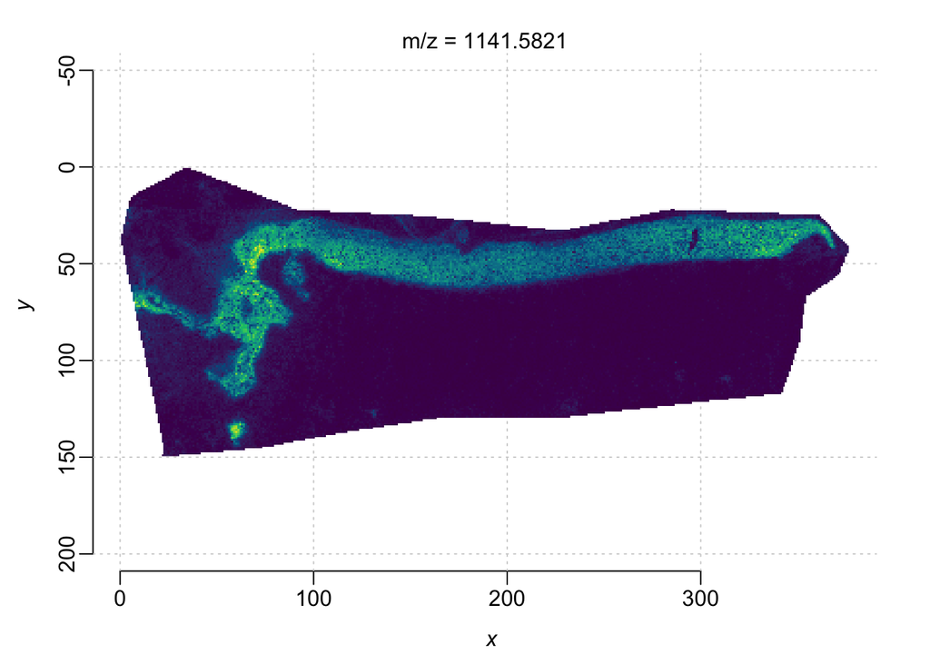

```r
image(m, i = cartilage_feature_ids, key = F)
```

There were seven m/z values indicative of background/ECM: 1570.676, 1571.679, 1572.681, 1592.667, 1593.672, 1594.679, 1608.631

- M/z 1570.676, 1571.679, 1572.681 are Glufib, +1, and +2 isotopes.
- M/z 1592.667, 1593.672, 1594.679 are *potentially* Glufib +23 sodium adducts and +1 and +2 isotopes.
- M/z 1608.631 is an identical spatial analog, similar enough to include in ROI segmentation.

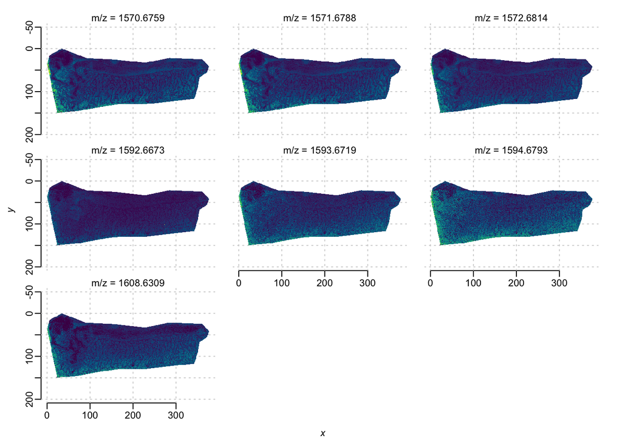

```r
image(m, i = background_feature_ids,
      scale = T,
     key = F)
```

### Segmenting cartilage

To begin we will select only the single cartilage marker as its own MSE.

```r
cartilage_features <- m[cartilage_feature_ids,]
```

Spatial-Dirichlet Gaussian mixture models (sDGMM) [(Guo et al. 2019)](https://doi.org/10.1093/bioinformatics/btz345) is an open-source, unsupervised clustering algorithm that groups pixels in single ion images into $k$ prespecified clusters using pixel intensity and spatial dependence of neighboring pixels. sDGMM is technically unsupervised but acts only on single features, facilitating a higher degree of control and replicability. We will use adaptive weights to better define segment edges.

Choosing the number of clusters is one way to affect a finer level of control over what sDGMM segments. In our testing we found 5 clusters, ordered by mean intensity with the first three assigned as cartilage, to yield the most consistent results across samples.

```r
set.seed(12345)
sdgmm <- spatialDGMM(cartilage_features,
                       k = 5,
                       r = 5,
                       weights = "adaptive",
                       verbose = F)

cartilage_vector <- recode_values(as.character(sdgmm$class[[1]]),
                               "5" ~ "other",
                               "4" ~ "other",
                               "3" ~ "cartilage",
                               "2" ~ "cartilage",
                               "1" ~ "cartilage")

pData(cartilage_features)$class <- cartilage_vector
```

Visualizing the 5 clusters, we can see that in this case segmenting more clusters gave finer control over cartilage boundaries.

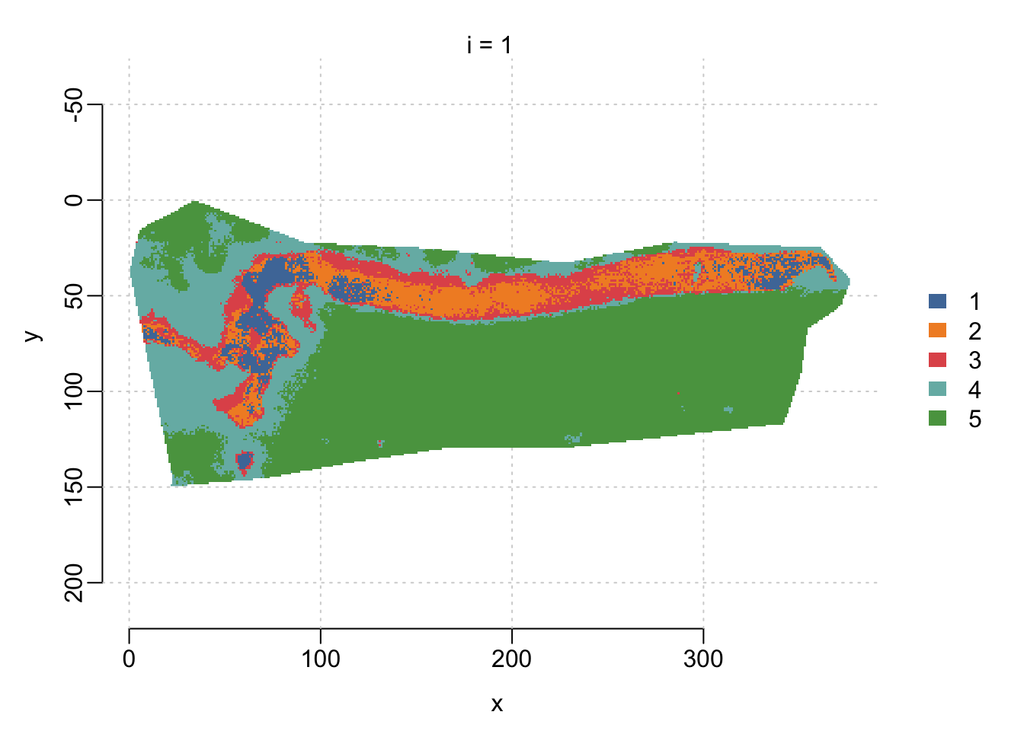

```r
image(sdgmm)
```

After collapsing the 5 segments into only two.

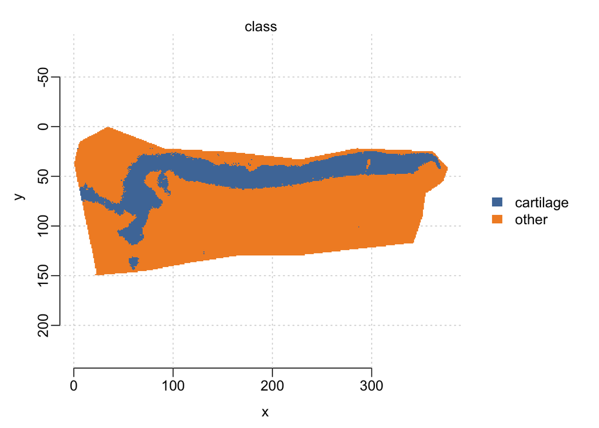

```r
image(cartilage_features, "class")
```

### Segmenting background and bone

Background/ECM and bone tissues are mutually exclusive from cartilage, so we will perform segmentation only on sample areas classified in the steps above as not cartilage. This offers another advantage: our markers to differentiate bone and background/ECM do not have to also differentiate cartilage.

First we will select only the background/ECM features and pixels not classified as cartilage.

```r
background_and_bone_features <- Cardinal::subset(m,
                                                 mz %in% mz(m)[background_feature_ids],
                                                 cartilage_vector=="other")
```

Unlike cartilage, we have selected seven features for background/ECM segmentation. Instead of segmenting each individually, we will first combine them into a single feature by using the pixel-wise mean. `condense_groups` (supplied from `Utilities.R`) uses the `group_ids` assigned by `grouping_df` to combine features into groups. The `agg_fun="mean"` specifies we want to combine groups via the pixel-wise mean.

```r
grouping_df <- tibble(feature_id = 1:length(mz(background_and_bone_features)),
                      group_id = rep(1, length(mz(background_and_bone_features))),
                      mz = mz(background_and_bone_features))

background_and_bone_features_condensed <- condense_groups(background_and_bone_features,
                                                          grouping_df,
                                                          verbose = FALSE,
                                                          agg_fun="mean",
                                                          na.rm=T)
```

Aggregating these features into a single feature by the pixel-wise mean concentrates signal and smooths out noise. Feature aggregation for ROI selection also presents some interesting possibilities - such as segmenting the pixel-wise ratio of two features.

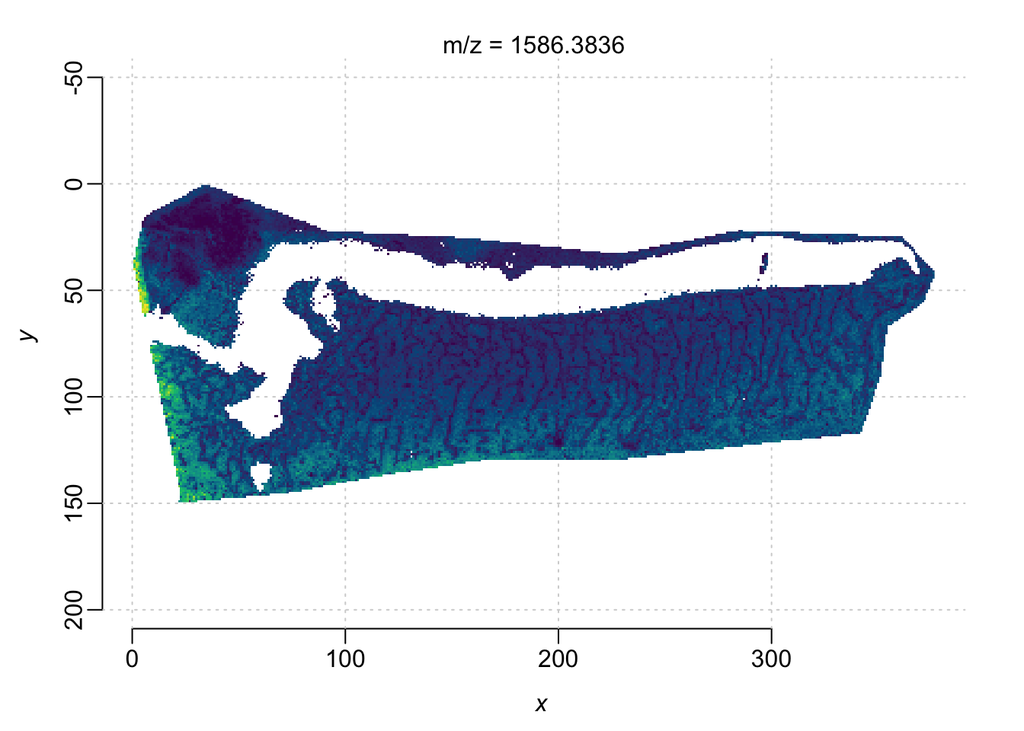

```r
image(background_and_bone_features_condensed, key = F)
```

Next we will segment the background/ECM feature aggregate using sDGMM. Like before, varying the number of clusters affects the segmentation results, especially at the segment boundaries.

```r
set.seed(12345)
sdgmm <- spatialDGMM(background_and_bone_features_condensed,
                     k = 4,
                     r = 1,
                     weights = "adaptive",
                     verbose = F)

bone_background_vector <- recode_values(as.character(sdgmm$class[[1]]),
                                     "4" ~ "bone",
                                     "3" ~ "background",
                                     "2" ~ "background",
                                     "1" ~ "background")
pData(background_and_bone_features)$class <- bone_background_vector
```

Visualizing the four clusters before collapsing.

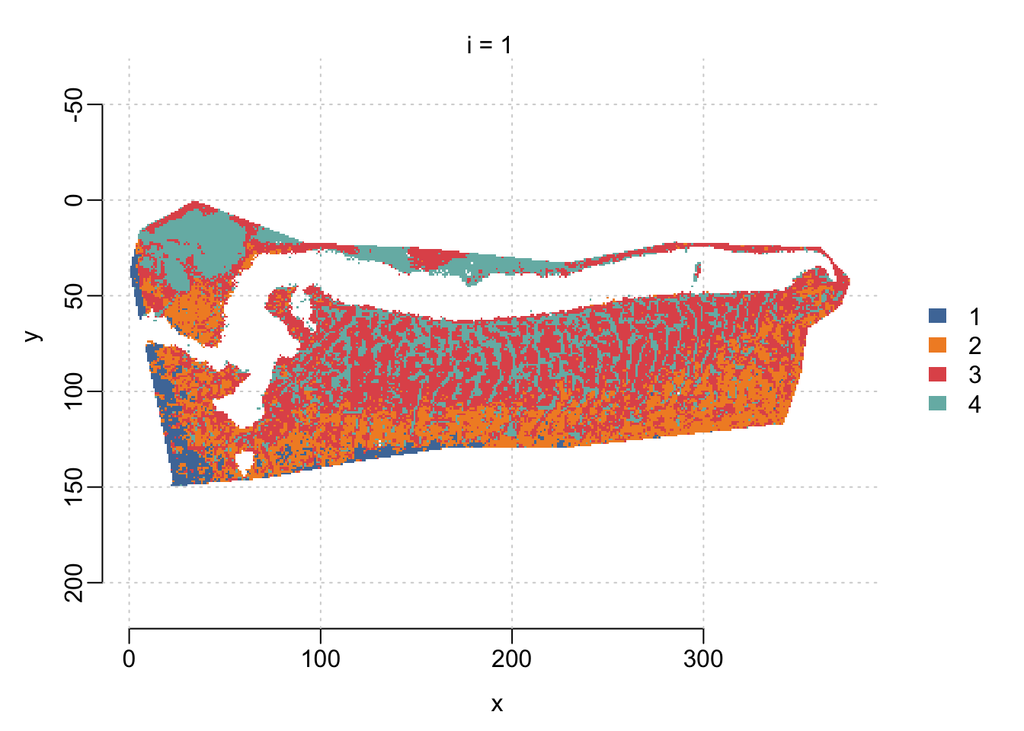

```r
image(sdgmm)
```

After collapsing into two classes, background and bone.

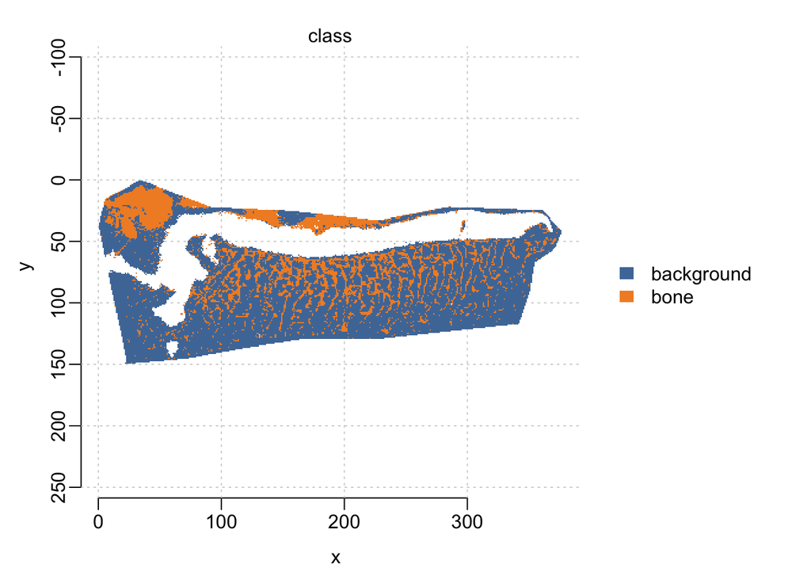

```r
image(background_and_bone_features, "class")
```

There are likely more underlying structures, especially in the bone ROI, that could be sub-segmented further. For the purpose of this demonstration we will conclude here, with three ROIs. The following combines ROI labels hierarchically.

```r
factor_tibble <- tibble(x = pData(cartilage_features)$x,
                        y = pData(cartilage_features)$y,
                        cartilage = cartilage_vector) |>
  left_join(tibble(x = pData(background_and_bone_features)$x,
                   y = pData(background_and_bone_features)$y,
                   bone_background = bone_background_vector),
            by = c("x","y")) |>
  mutate(zone = as.factor(ifelse(is.na(bone_background),
                                 "cartilage",
                                 bone_background)))

pData(m)$tissue_zone <- factor_tibble$zone
```

After segmentation and label combination we can visualize the final result for this sample.

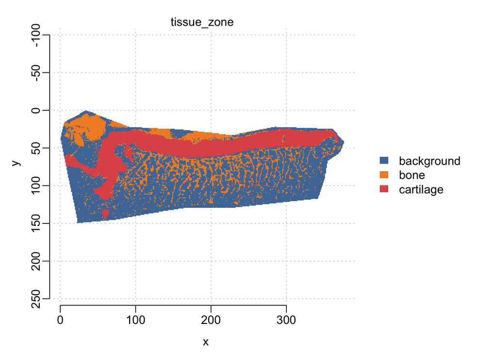

```r
image(m, "tissue_zone")
```

## Segment all samples

Now we will repeat this procedure on all samples, saving the ROI labels in a named list and a data frame for visualization.

```r
bp <- SnowfastParam(workers = 16L, force.GC = TRUE)

mse_list_segmented <- BiocParallel::bplapply(
  mse_list_pp,
  function(mse) {

    source(file.path("Utilities.R"))

    # bug in matter - needs to be here for now
    setMethod("as.vector", "sparse_arr",
      function(x, mode = "any") {
        if ( mode != "any" )
        matter::type(x) <- mode
        y <- as.vector(x[])
        names(y) <- NULL
        y
      })

    cartilage_feature_approx <- 1141.582
    cartilage_feature_ids <- features(mse,
      mz = cartilage_feature_approx)

    background_feature_approx <- c(1570.676,
                                  1571.679,
                                  1572.681,
                                  1592.667,
                                  1593.672,
                                  1594.679,
                                  1608.631)
    background_feature_ids <- features(mse,
      mz = background_feature_approx)

    ## --- cartilage vs other ---
    cartilage_features <- mse[cartilage_feature_ids, ]

    set.seed(12345, kind = "L'Ecuyer-CMRG")
    if (runNames(mse) %in% c("6924-CAD-medial")) {
      # 6924-CAD-medial needed 6 clusters
    sdgmm1 <- spatialDGMM(
          cartilage_features,
          k = 6,
          r = 5,
          weights = "adaptive",
          verbose = F
        )
    } else {
      sdgmm1 <- spatialDGMM(
          cartilage_features,
          k = 5,
          r = 5,
          weights = "adaptive",
          verbose = F
        )
    }

    if (runNames(mse) %in% c("6954-OA-medial")) {
      # 6954-OA-medial needed different grouping
      cartilage_vector <- recode_values(
        as.character(sdgmm1$class[[1]]),
        "5" ~ "other",
        "4" ~ "other",
        "3" ~ "other",
        "2" ~ "cartilage",
        "1" ~ "cartilage"
      )
    } else if (runNames(mse) %in% c("6924-CAD-medial")) {
      cartilage_vector <- recode_values(
        as.character(sdgmm1$class[[1]]),
        "6" ~ "other",
        "5" ~ "other",
        "4" ~ "other",
        "3" ~ "cartilage",
        "2" ~ "cartilage",
        "1" ~ "cartilage"
      )
    } else {
      cartilage_vector <- recode_values(
        as.character(sdgmm1$class[[1]]),
        "5" ~ "other",
        "4" ~ "other",
        "3" ~ "cartilage",
        "2" ~ "cartilage",
        "1" ~ "cartilage"
      )
    }


    background_and_bone_features <- Cardinal::subset(
      mse,
      background_feature_ids,
      cartilage_vector == "other"
    )

    grouping_df <- tibble(
      feature_id = seq_along(mz(background_and_bone_features)),
      group_id   = 1L,
      mz         = mz(background_and_bone_features)
    )

    background_and_bone_features_condensed <- condense_groups(
      background_and_bone_features,
      grouping_df,
      verbose = FALSE,
      agg_fun = "mean",
      na.rm = TRUE
    )

    set.seed(12345, kind = "L'Ecuyer-CMRG")
    sdgmm2 <- spatialDGMM(
      background_and_bone_features_condensed,
      k = 4,
      r = 1,
      weights = "adaptive",
      verbose = FALSE
    )

    bone_background_vector <- recode_values(
      as.character(sdgmm2$class[[1]]),
      "4" ~ "bone",
      "3" ~ "background",
      "2" ~ "background",
      "1" ~ "background"
    )

    ## --- assemble zones ---
    factor_tibble <- tibble(
      x = pData(cartilage_features)$x,
      y = pData(cartilage_features)$y,
      cartilage = cartilage_vector
    ) |>
      left_join(
        tibble(
          x = pData(background_and_bone_features)$x,
          y = pData(background_and_bone_features)$y,
          bone_background = bone_background_vector
        ),
        by = c("x", "y")
      ) |>
      mutate(
        zone = factor(ifelse(is.na(bone_background),
                             "cartilage",
                             bone_background))
      )

    pData(mse)$tissue_zone <- factor_tibble$zone

    mse
  },
  BPPARAM = bp
)

pdata_list <- lapply(names(mse_list_segmented), function(nm) {
  dt <- as.data.table(pData(mse_list_segmented[[nm]]))
  dt[, id := nm]
  dt
})

hc_class_plotting_frame <- rbindlist(pdata_list)
roi_list <- hc_class_plotting_frame[, .(x, y, run, tissue_zone)]

save(roi_list, file = file.path("Outputs", "roi_list.Rdata"))
```

Visualization of all samples’ ROIs.

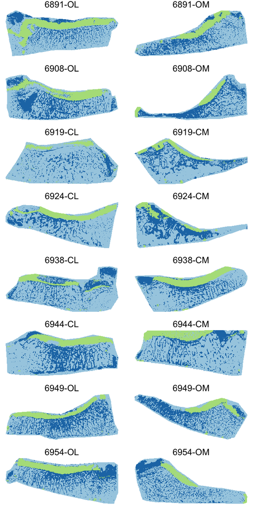

```r
ggplot(hc_class_plotting_frame |>
         left_join(name_tibble, by = join_by(run)) |>
         mutate(roi = recode_values(tissue_zone,
                                 "bone" ~ "Bone",
                                 "background" ~ "Background",
                                 "cartilage" ~ "Cartilage")),
       aes(x = x, y = -1*y, fill = roi)) +
  geom_tile() +
  theme_void() +
  facet_wrap("tid", scales = "free", ncol = 2) +
  scale_fill_brewer(palette = "Paired") +
  theme(legend.position = "none") +
  labs(fill = "ROI")
```

# Normalization

Normalization exists to decrease nuisance variation and enhance signal, but relies on a set of assumptions. Briefly, normalization schemes that scale by a global constant (e.g., TIC, median) assume that few analytes are truly changing and that the amount of signal is constant between spectra. Reference normalization assumes the signal of the reference is constant across spectra. Normalization remains an active field of research, with few definite recommendations available aside from the necessity of some normalization scheme.

```r
library(dplyr)
library(tibble)
library(data.table)
library(Cardinal)

source(file.path("Utilities.R"))

RNGkind("L'Ecuyer-CMRG")

setCardinalVerbose(verbose = FALSE)

options(stringsAsFactors = FALSE)
```

We will perform normalization on the unified dataset.

```r
m <- readMSIData(file.path("Data",
  "Preprocessing",
  "Recalibrated-Picked-Aligned-FreqFiltered05perRun.imzML"))
```

Normalization should only be performed on features which represent true biology. Additionally, features with very high intensity - far greater than endogenous analytes - will bias normalization and should be dropped. We will remove the mass calibrant along with its isotopes and adducts, as their very high intensity would otherwise dominate the total ion current.

```r
bg_mz_approx <- c(1570.676,
                  1571.679,
                  1572.681,
                  1592.667,
                  1593.672,
                  1594.679,
                  1608.631)

bg_idx <- features(m, mz=bg_mz_approx)
```

```r
intensity(m) <- as.matrix(intensity(m))

m <- subsetFeatures(m, mz %ni% mz(m)[bg_idx])
```

## A note on sparsity

Sparsity of pixels and features is ubiquitous in MSI. Sparsity is generally a mix of concepts: zero intensity, intensity below the limit of detection, and missing values. Although each is subtly different, they are highly interlinked due to the nature of mass spectrometry. In practice, they behave similarly, but these conceptual similarities do not extend to preprocessing. Zero and missing values behave very differently in a mathematical sense. In general, zeros are retained while missing values are dropped. Zeros bias summaries towards zero, especially means. Missing values are often dropped, meaning that summaries are biased larger towards non-missing values. There is no good way around this predicament other than to reduce sparsity by defining more stringent ROIs and filtering highly sparse features. Regardless, at the time of normalization one will need to choose a method (leaving zeros as they are, or replacing them with NAs) and stick with it through analysis.

## Preparing spectra for normalization

We will use total ion current (TIC) normalization, which scales each spectrum by its summed intensity. This assumes that the total amount of ionized material is comparable across pixels, so that differences in overall signal reflect nuisance variation rather than biology. We rescale the normalized spectra to the median per-pixel TIC, which keeps intensities on an interpretable scale comparable to the raw data (left unset, Cardinal scales instead to the number of features). Like other global-constant methods, TIC is sensitive to sparse and outlier pixels, which we address with a per-pixel filter below.

We will attach the ROI labels to each pixel for use in later steps. The tissue zones are not subset here, but background and low-quality pixels are removed before normalization; tissue areas are subset in downstream steps.

```r
load(file.path("Outputs","roi_list.Rdata"))

# confirm coords are in the correct order
stopifnot(
  all(pData(m)$x == roi_list$x),
  all(pData(m)$y == roi_list$y),
  all(pData(m)$run == roi_list$run)
)

pData(m)$tissue_zone <- roi_list$tissue_zone
```

Before normalizing, we restrict to non-background pixels and apply a per-pixel quality filter, dropping pixels with fewer than 100 detected peaks or with a total ion current outside the 2nd to 98th percentile within each run. This removes sparse and aberrant pixels that would otherwise distort per-pixel normalization.

```r
m <- m |>
  subsetPixels(tissue_zone != "background") |>
  summarizePixels(stat = c(tic = "sum", nnz = "nnzero"), na.rm = TRUE,
    chunkopts = list(nchunks = if (hpc) 20L else 60L),
    BPPARAM = SnowfastParam(workers = 5L, force.GC = T))

qc <- as.data.table(pData(m))
qc[, `:=`(lo = quantile(tic, 0.02), hi = quantile(tic, 0.98)), by = run]

m <- subsetPixels(m, qc$nnz >= 100 & qc$tic >= qc$lo & qc$tic <= qc$hi)
```

```r
tic_scale <- median(pData(m)$tic, na.rm = TRUE)

normalized <- m |>
        normalize(method = "tic", scale = tic_scale) |>
        process(chunkopts = list(nchunks = if (hpc) 20L else 60L),
          BPPARAM=SnowfastParam(workers = 5L, force.GC = T)) |>
        summarizePixels(stat = c(tic = "sum", mean = "mean", nnzero = "nnzero"),
          na.rm = T, chunkopts = list(nchunks = if (hpc) 20L else 60L),
          BPPARAM=SnowfastParam(workers = 5L, force.GC = T)) |>
        summarizeFeatures(stat = c(sd = "sd", mean = "mean", nnzero = "nnzero"),
          na.rm = T, chunkopts = list(nchunks = if (hpc) 20L else 60L),
          BPPARAM=SnowfastParam(workers = 5L, force.GC = T))
```

Finally, save the normalized dataset.

```r
writeMSIDataSafe(normalized, file.path("Data",
                                        "Preprocessing",
                                        "normalized.imzML"))
```

Below creates figures from the paper.

```r
png(filename = file.path("Recreated-Figures",
      "Figure-Peakpicking-Preprocessed.png"),
    height = 500, width = 600, pointsize = 20)

print(plot(normalized, "mean",
     ylab = "Mean Pixel Intensity",
     run = "6891-OA-lateral",
     grid = F))

dev.off()
```

```r
knitr::kable(normalized |>
  subsetPixels(run == "6891-OA-lateral") |>
  summarizeFeatures(stat = c("mean", "sd"), na.rm = T) |>
  fData() |>
  as_tibble() |>
  filter(mean != 0 | sd != 0) |>
  mutate(cv = sd/mean) |>
  summarise(mean_cv = mean(cv, na.rm = T)))
```

| mean_cv |
| --- |
| 0.6595743 |